# EDA

Jinane Jouni

Dec 19, 2025

# —– 0. Setup —————————————————

Let numbers display in decimals and not scientific notation

```r
options(scipen = 999)
```

Set seed also

```r
set.seed(12345)
```

Library Records is essential to run most of the functions available on github.

To install

```r
## library Records from Github
#devtools::install_github("jj-64/Records")
```

Load library

```r
#library(Records)
devtools::load_all(".")
```

```
## ℹ Loading Records
```

# —– 1. Load data —————————————

Load feature matrix

```r
#data("feature_matrix", package = "Records")
load("C:/Users/User/Documents/Records/data/feature_matrix.rda")
```

Promise data

```r
str(feature_matrix)
```

```
## 'data.frame':    3600 obs. of  111 variables:
##  $ ave                                : num  1.21 -3.25 13.49 -7.44 -1.26 ...
##  $ std                                : num  2.3 3.99 7.11 6.22 2.66 ...
##  $ cv                                 : num  1.898 -1.227 0.527 -0.836 -2.117 ...
##  $ median                             : num  1.5 -4.56 15.98 -7.75 -1.54 ...
##  $ iqr                                : num  3.01 6.83 12.09 11.14 2.2 ...
##  $ skewness                           : num  -0.508 0.423 -0.303 -0.126 0.481 ...
##  $ kurtosis                           : num  2.72 1.96 1.86 1.64 3.88 ...
##  $ min                                : num  -4.44 -9.14 -1.26 -17.57 -6.6 ...
##  $ range                              : num  9.53 13.56 25.12 20.8 12.7 ...
##  $ slope                              : num  -0.0419 -0.1602 0.3175 -0.2676 0.0546 ...
##  $ slope_R2                           : num  0.157 0.765 0.948 0.879 0.2 ...
##  $ kendall_tau                        : num  -0.216 -0.647 0.889 -0.741 0.213 ...
##  $ diff_mean                          : num  0.01371 -0.10798 0.30618 -0.17082 -0.00946 ...
##  $ diff_sd                            : num  0.93 0.914 1.033 0.961 1.033 ...
```

[output cut: 86 more lines]

Basic dimensions

```r
n_obs  <- nrow(feature_matrix)
n_feat <- ncol(feature_matrix)

cat("Observations:", n_obs, "\n")
```

```
## Observations: 3600
```

```r
cat("Features:", n_feat, "\n")
```

```
## Features: 111
```

# —– 2. Missingness and degeneracy ————————–

Check Missing values per feature

```r
na_summary <- tibble(
  feature = names(feature_matrix),
  n_na    = colSums(is.na(feature_matrix)),
  pct_na  = colMeans(is.na(feature_matrix))
) %>% dplyr::arrange(desc(pct_na))

if(sum (na_summary$n_na) >0 ) print(na_summary %>% dplyr::filter(n_na > 0)) else print("no NA")
```

```
## [1] "no NA"
```

Remove NAs if needed. Note that database is large so removing few NAs won’t bias the analysis.

```r
feature_matrix=feature_matrix[complete.cases(feature_matrix),]
```

new basic dimensions after NAs

```r
n_obs  <- nrow(feature_matrix)
n_feat <- ncol(feature_matrix)

cat("Observations:", n_obs, "\n")
```

```
## Observations: 3600
```

```r
cat("Features:", n_feat, "\n")
```

```
## Features: 111
```

# —– 3. Feature_only data ———————————-

Most of the analysis will be on the matrix containing only numeric values. We will exclude other idetification columns such as label, series_id, label_m (submodel), series, and series length. We obtain the “feature_only” matrix.

```r
feature_names <- lubridate::setdiff(names(feature_matrix), c("Max_logLik","series_id", "label", "label_m", "series", "T_length"))

feature_only <- feature_matrix[, colnames(feature_matrix) %in% (feature_names)]
head(feature_only,1)
```

```
##        ave      std      cv   median     iqr   skewness kurtosis       min
## 1 1.213598 2.302947 1.89762 1.501492 3.00675 -0.5078246 2.720586 -4.436368
##      range       slope  slope_R2 kendall_tau  diff_mean   diff_sd  diff_mad
## 1 9.525438 -0.04190118 0.1572455  -0.2158559 0.01370909 0.9299302 0.7493172
##    diff_skew sign_change_rate  rec_rate rec_high_rate rec_high_back_rate
## 1 0.03964064        0.4657534 0.1333333     0.1333333          0.1333333
##   rec_rate_ratio rec_gap_median rec_gap_sd rec_gap_cv rec_gap_back_median
## 1              1              1   3.609401   1.476573                   4
##   max_gap_over_n frac_rec_first_half frac_rec_last_quarter span_norm
## 1           0.16                   1                     0 0.2933333
##   entropy_shann dom_period dom_power extreme_2sd ndiff_needed ljung_pvalue
## 1     0.3926745       37.5  76.86776  0.05333333            1            0
##   local_minima local_maxima rec_low_rate rec_low_back_rate rec_low_rate_ratio
## 1    0.2328767    0.2328767         0.12         0.1066667              1.125
##   rec_low_gap_median rolling_mean_instab.mean_instab
## 1                  1                        1.764507
##   rolling_var_instab.var_instab rolling_mean_sd_ratio.mean_sd_ratio    x_acf1
## 1                     0.7061982                           0.9910699 0.9144296
##    x_acf10 diff1_acf1 diff1_acf10 diff2_acf1 diff2_acf10 x_pacf5 diff1x_pacf5
## 1 3.198432  0.0610489  0.05221625  -0.479612   0.2750156 0.85841   0.02074347
##   diff2x_pacf5   ARCH.LM crossing_points   entropy flat_spots  arch_acf
## 1    0.4414399 0.7100754               6 0.5715502          5 0.1760379
##   garch_acf   arch_r2  garch_r2     hurst     alpha         beta  lumpiness
## 1 0.1757564 0.1769061 0.1826884 0.9926259 0.9998998 0.0001000035 0.08302849
##   stability nonlinearity std1st_der spreadrandomlocal_meantaul_50
## 1 0.8292559    0.1260607     0.4038                         11.97
##   spreadrandomlocal_meantaul_ac2 nperiods seasonal_period     trend
## 1                           7.71        0               1 0.9223246
##            spike linearity  curvature    e_acf1   e_acf10 logLik_all_iid_gumbel
## 1 0.000002238779 -3.268339 -0.7361104 0.2730635 0.2929442             -207.9492
##   logLik_all_iid_norm logLik_all_iid_frechet logLik_all_iid_weibull
## 1           -168.4846              -2827.781                   -Inf
##   logLik_rec_iid_gumbel logLik_rec_iid_norm logLik_rec_iid_frechet
## 1             -53.58276           -24.92726               -97.9743
##   logLik_rec_iid_weibull logLik_all_DTRW_norm logLik_all_DTRW_cauchy
## 1                   -Inf            -145.7272              -213.7519
##   logLik_rec_DTRW_norm logLik_rec_DTRW_cauchy logLik_all_LDM_norm
## 1             -17.6058              -23.11272           -180.5925
##   logLik_all_LDM_gumbel logLik_all_LDM_frechet logLik_all_LDM_weibull
## 1             -208.0448              -2821.111                   -Inf
##   logLik_rec_LDM_norm logLik_rec_LDM_gumbel logLik_rec_LDM_frechet
## 1           -25.07293             -45.71963              -89.35691
##   logLik_rec_LDM_weibull logLik_all_YNM_norm logLik_all_YNM_gumbel
## 1                   -Inf           -186.0547             -224.9422
##   logLik_all_YNM_frechet logLik_all_YNM_weibull logLik_rec_YNM_norm
## 1              -4518.605                   -Inf           -27.65773
##   logLik_rec_YNM_gumbel logLik_rec_YNM_frechet logLik_rec_YNM_weibull
## 1             -72.03403              -124.8546                   -Inf
```

```r
# feature_only <- feature_matrix[, sapply(feature_matrix, is.numeric)]
```

In case there are any problems with the feature_only matrix, we will convert all columns to numerical

```r
feature_only <- feature_only %>% mutate_if(is.factor, as.character) %>% mutate_all(as.numeric)
```

For later use, we would need to keep the label of each series stored in “regime” vector.

```r
regime = feature_matrix$label
```

Basic dimensions

```r
n_obs  <- nrow(feature_only)
n_feat <- ncol(feature_only)

cat("Observations:", n_obs, "\n")
```

```
## Observations: 3600
```

```r
cat("Features:", n_feat, "\n")
```

```
## Features: 106
```

# —– 4. Degeneracy —————————————

Check for constant or near-constant features.

```r
variance_summary <- tibble(
  feature = names(feature_only),
  variance = apply(feature_only, 2, var, na.rm = TRUE),
  unique_vals = apply(feature_only, 2, function(z) length(unique(z)))
) %>% dplyr::arrange(variance)
```

These features will be removed immediately as they are obviously redundant and degenerate.

```
  Interpretation:

  Zero variance → remove

  Two unique values → possible indicator, verify meaning

  High NA → consider imputation or exclusion
```

```r
degenerate_features <- subset(variance_summary , variance == 0 | unique_vals <=2)

if (nrow(degenerate_features) > 0) {
  warning("Degenerate or quasi-degenerate features detected")
  print(degenerate_features)
}
```

```
## # A tibble: 2 × 3
##   feature         variance unique_vals
##   <chr>              <dbl>       <int>
## 1 nperiods               0           1
## 2 seasonal_period        0           1
```

Remove degenerate features

```r
feature_only = feature_only[, !(colnames(feature_only) %in%  degenerate_features$feature)]
```

For later processing, replace -Inf with -1e5 ( only fix LogLik values)

```r
feature_only[grep("^logLik_", names(feature_only))] <-
  lapply(feature_only[grep("^logLik_", names(feature_only))], function(x) {
    x[x < -1e5] <- -1e5#Inf
    x[!is.finite(x)] <- -1e5
    x
  })
```

# —– 5 . Supervised PCA (Sanity Check) —————-

The aim is to check if generated dataset is really separable and can be well identified. i.e if the four models are well identified.

```r
pca <- FactoMineR::PCA(
  feature_only,
  scale.unit = TRUE,
  graph = FALSE
)
```

Variance explained Scree plot

Interpretation : Few PCs explaining most variance → redundancy

We aim to have large number of PCs to explain more than 70-90% of the variance.

```
Look for:

Sharp drop (elbow)

Flat tail → noise
```

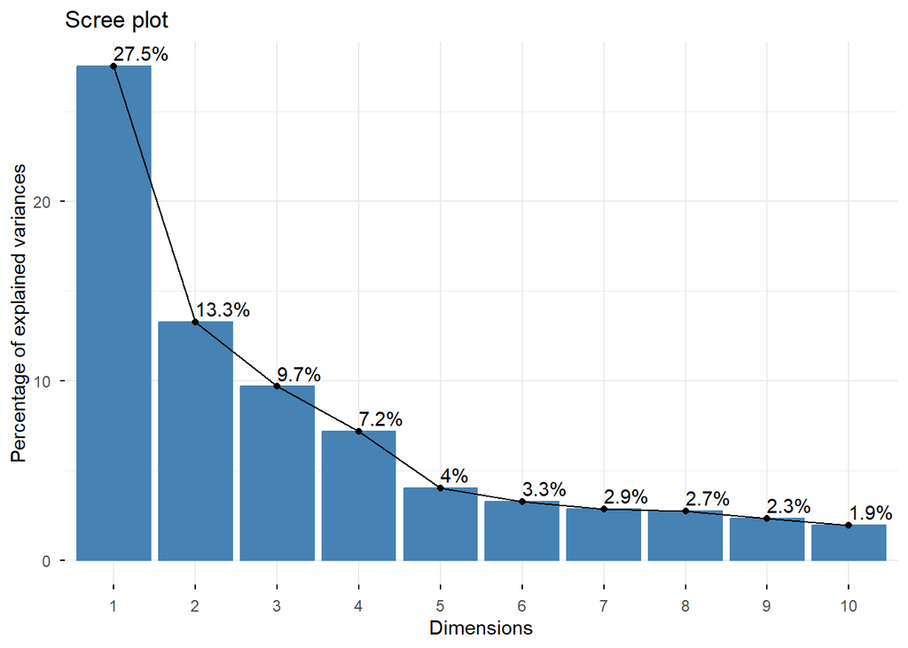

```r
factoextra::fviz_eig(pca, addlabels = TRUE)
```

How many components should you keep?

You should not keep components based on visualization alone.

Explained variance criterion (baseline)

```
  Rules of thumb:

  1 - Keep components explaining 70–90% of variance

  2 - Typically yields 10–30 components from 100 variables
```

```r
which(cumsum(pca$eig[,2]) >= 90)[1]
```

```
## comp 25
##      25
```

How to use PCA with known groups

We have 4 known models, so PCA should be combined with a supervised method.

Visual inspection only (exploratory) Plot individuals and should be clearly clustered into four distinct groups.

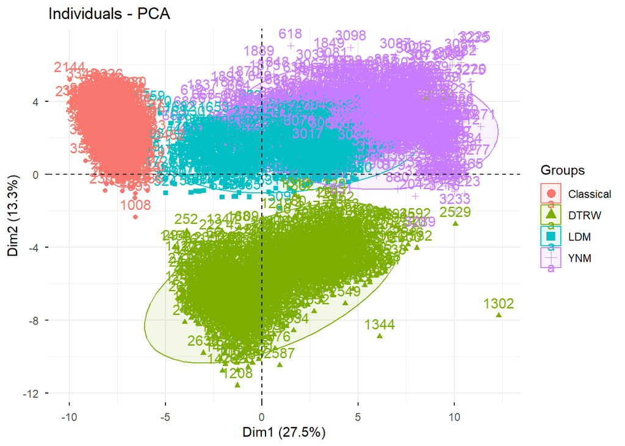

```r
factoextra::fviz_pca_ind(pca,
             habillage = regime,
             addEllipses = TRUE,
             ellipse.level = 0.95
)
```

Feature Contribution to first PCs

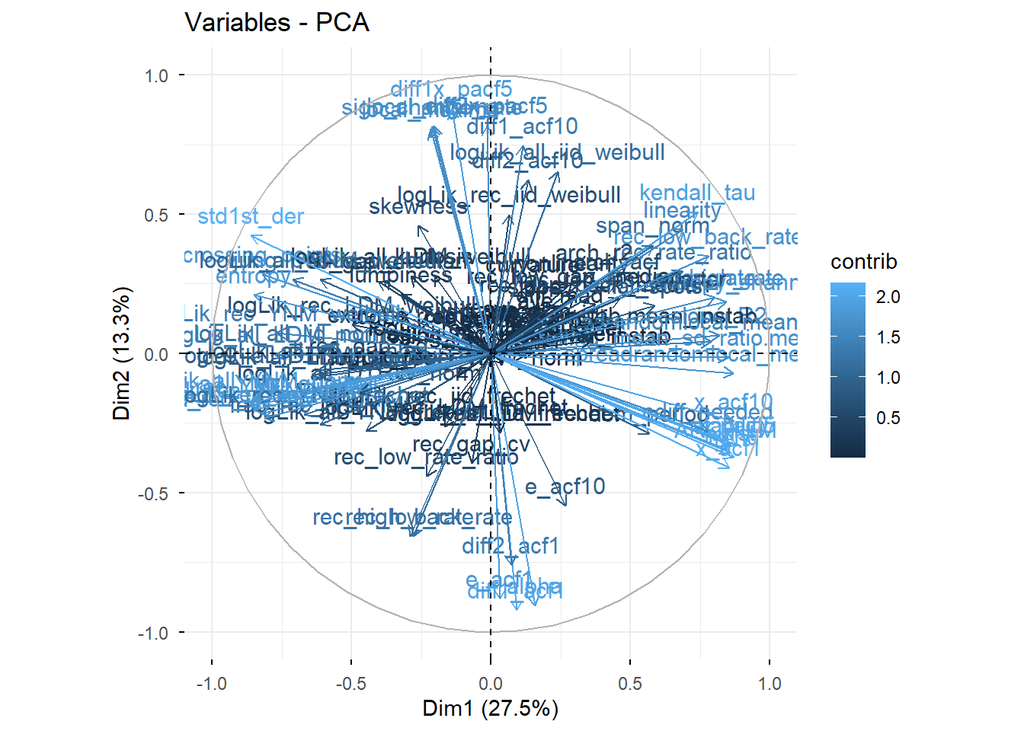

```r
#loadings
# print(pca$var$coord)

factoextra::fviz_pca_var(pca, col.var = "contrib")
```

which variables define each PC

```r
head(pca$var$contrib, 10)
```

```
##                Dim.1        Dim.2        Dim.3      Dim.4       Dim.5
## ave      0.090898562 0.1049960773 0.0360542114 2.84095118 0.923676903
## std      0.084229890 0.0001871217 6.8965334644 3.53680845 0.006379518
## cv       0.000315819 0.0595910986 0.0002122889 0.02974517 0.196313093
## median   0.084440944 0.0481225667 0.1099727137 0.90172367 1.235951241
## iqr      0.480431154 0.0400124160 1.2344478932 0.27097442 2.952917160
## skewness 0.234966547 1.5276576986 0.6507292249 1.68271412 4.541267487
## kurtosis 0.144831699 0.5592975759 1.5190757941 1.59812471 3.325099033
## min      0.005549955 0.0158553972 5.2289311919 5.53784054 0.079738659
## range    0.056969895 0.0021061589 6.7609049170 3.27258350 0.017655340
## slope    0.088375696 0.2050385462 2.6619737886 6.53871760 0.267591931
```

# —– 6. k-means preview ———————–

The elbow Method helps determine the optimal number of clusters.

There should be 4 clusters each for one model.

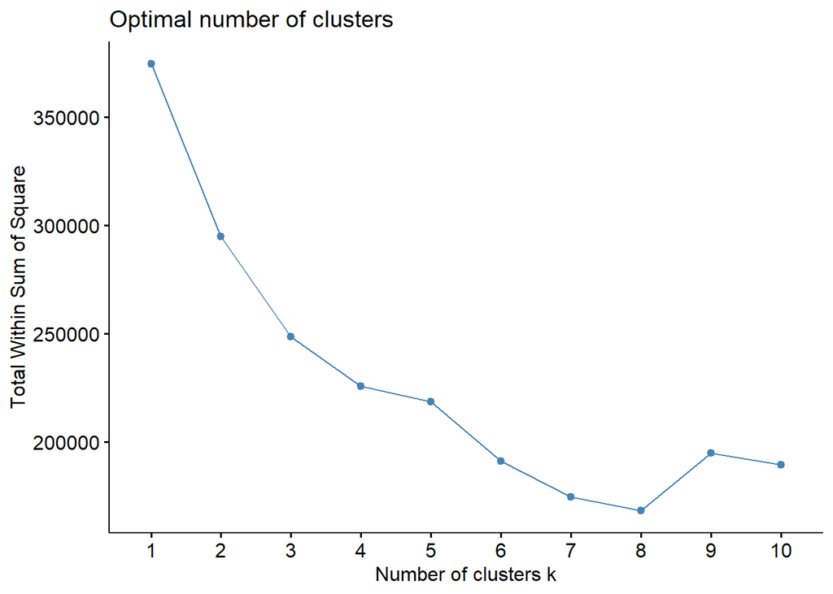

```r
factoextra::fviz_nbclust(scale(feature_only), kmeans, method = "wss")
```

Run k-means

```r
k_means_result <- stats::kmeans(scale(feature_only), centers = 4, nstart = 20)
```

Plot kmeans. They should be 4 distinct clusters

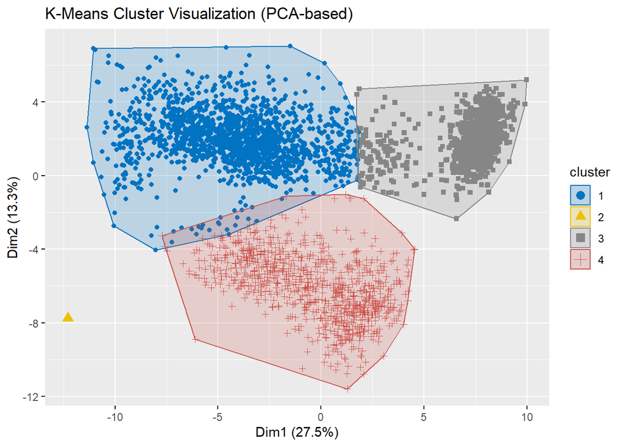

```r
factoextra::fviz_cluster(k_means_result,
             data = scale(feature_only),
             geom = "point", # Use points to represent observations
             ellipse.type = "convex", # Drawing a concentration ellipse around each cluster
             palette = "jco", # Color palette
             main = "K-Means Cluster Visualization (PCA-based)")
```

Clusters

Check whether features contain structure before labels

If clusters align with known regimes → strong signal

If not → classification may rely on subtle margins

```r
clusters = data.frame( features = regime, submodel = feature_matrix$label_m, cluster = k_means_result$cluster)
table(clusters)
```

```
## , , cluster = 1
##
##            submodel
## features    cauchy frechet gumbel norm pareto uniform weibull
##   Classical      0       0      0    0      0       0       0
##   DTRW          16       0      0    5      0       7       0
##   LDM            0     279      0  213      0       0     280
##   YNM            0     287      0    0    300       0     300
##
## , , cluster = 2
##
##            submodel
## features    cauchy frechet gumbel norm pareto uniform weibull
##   Classical      0       0      0    0      0       0       0
##   DTRW           1       0      0    0      0       0       0
##   LDM            0       0      0    0      0       0       0
##   YNM            0       0      0    0      0       0       0
##
## , , cluster = 3
##
##            submodel
## features    cauchy frechet gumbel norm pareto uniform weibull
##   Classical      0     300    300    0      0       0     300
##   DTRW           0       0      0    0      0       0       0
##   LDM            0      21      0   82      0       0      19
##   YNM            0      13      0    0      0       0       0
##
## , , cluster = 4
##
##            submodel
## features    cauchy frechet gumbel norm pareto uniform weibull
##   Classical      0       0      0    0      0       0       0
##   DTRW         283       0      0  295      0     293       0
##   LDM            0       0      0    5      0       0       1
##   YNM            0       0      0    0      0       0       0
```

# —– 7. Univariate Description —————————

Univariate summary statistics

```
What to look for

Heavy skewness → log / rank transforms

Extreme kurtosis → tail-driven statistics (records, extremes)
```

```r
desc_stats <- psych::describe(feature_only)

print(desc_stats)
```

```
##                                     vars    n       mean           sd
## ave                                    1 3600      53.42       521.44
## std                                    2 3600      82.84       738.02
## cv                                     3 3600       0.73         4.35
## median                                 4 3600      45.21       519.56
## iqr                                    5 3600      94.96       336.71
## skewness                               6 3600       0.65         1.19
## kurtosis                               7 3600       4.51         6.40
## min                                    8 3600     -80.25      3544.22
## range                                  9 3600     340.42      3770.11
## slope                                 10 3600       1.18        10.03
## slope_R2                              11 3600       0.51         0.38
## kendall_tau                           12 3600       0.44         0.48
## diff_mean                             13 3600       0.84        36.37
## diff_sd                               14 3600      34.87       380.89
## diff_mad                              15 3600      11.53        56.56
## diff_skew                             16 3600       0.17         1.81
## sign_change_rate                      17 3600       0.62         0.08
## rec_rate                              18 3600       0.15         0.09
## rec_high_rate                         19 3600       0.15         0.09
## rec_high_back_rate                    20 3600       0.05         0.05
## rec_rate_ratio                        21 3600       7.27         8.99
## rec_gap_median                        22 3600       4.69         5.47
## rec_gap_sd                            23 3600       8.80         9.19
## rec_gap_cv                            24 3600       1.08         0.46
## rec_gap_back_median                   25 3600      20.57        40.00
## max_gap_over_n                        26 3600       0.24         0.17
## frac_rec_first_half                   27 3600       0.69         0.21
## frac_rec_last_quarter                 28 3600       0.15         0.14
## span_norm                             29 3600       0.73         0.30
## entropy_shann                         30 3600       0.38         0.16
## dom_period                            31 3600      49.80        50.38
## dom_power                             32 3600 3969889.08 192452807.87
## extreme_2sd                           33 3600       0.03         0.02
## ndiff_needed                          34 3600       0.76         0.46
## ljung_pvalue                          35 3600       0.13         0.27
## local_minima                          36 3600       0.31         0.04
## local_maxima                          37 3600       0.31         0.04
## rec_low_rate                          38 3600       0.05         0.05
## rec_low_back_rate                     39 3600       0.19         0.15
```

[output cut: 365 more lines]

```
## logLik_all_LDM_gumbel                   2.59       8.15
## logLik_all_LDM_frechet                 -1.90     801.23
## logLik_all_LDM_weibull                 -1.21     748.48
## logLik_rec_LDM_norm                  1152.44      48.43
## logLik_rec_LDM_gumbel                 376.99      82.37
## logLik_rec_LDM_frechet                 -1.25     741.46
## logLik_rec_LDM_weibull                 -1.99     831.93
## logLik_all_YNM_norm                    -1.95     806.11
## logLik_all_YNM_gumbel                  -1.92     801.95
## logLik_all_YNM_frechet                 -0.14     647.53
## logLik_all_YNM_weibull                  0.56     626.65
## logLik_rec_YNM_norm                    -1.96     809.61
## logLik_rec_YNM_gumbel                  -1.93     807.05
## logLik_rec_YNM_frechet                 -1.27     732.27
## logLik_rec_YNM_weibull                 -1.48     771.11
```

# —– 8. Correlation analysis —————————-

Pairwise correlation (Spearman recommended)

```r
cor_mat <- cor(feature_only, use = "pairwise.complete.obs", method = "spearman")
```

Visual inspection

We aim to have only clear (low correlation) zones.

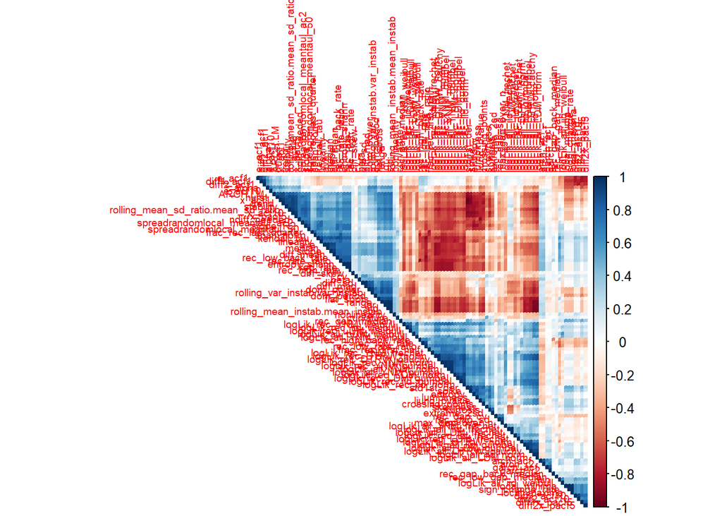

```r
corrplot::corrplot(cor_mat,
         method = "color",
         type = "upper",
         tl.cex = 0.6,
         order = "hclust")
```

Identify highly correlated pairs

```
Decision rule

|ρ| > 0.95 → keep one representative
Prefer:
More interpretable
Lower variance inflation
Better downstream SHAP signal
```

```r
high_corr <- which(abs(cor_mat) > 0.95 & abs(cor_mat) < 1, arr.ind = TRUE)

high_corr_pairs <- tibble(
  feature_1 = rownames(cor_mat)[high_corr[,1]],
  feature_2 = colnames(cor_mat)[high_corr[,2]],
  rho = cor_mat[high_corr]
   ) %>% dplyr::filter(feature_1 != feature_2)

high_corr_pairs <- high_corr_pairs %>%
  rowwise() %>%
  dplyr::mutate(pair = paste(sort(c(feature_1, feature_2)), collapse = "_")) %>%
  ungroup() %>%
  dplyr::distinct(pair, .keep_all = TRUE) %>%
  dplyr::select(-pair)


print(high_corr_pairs)
```

```
## # A tibble: 25 × 3
##    feature_1                       feature_2          rho
##    <chr>                           <chr>            <dbl>
##  1 median                          ave              0.970
##  2 iqr                             std              0.987
##  3 range                           std              0.988
##  4 rolling_mean_instab.mean_instab std              0.989
##  5 range                           iqr              0.963
##  6 rolling_mean_instab.mean_instab iqr              0.988
##  7 rolling_mean_instab.mean_instab range            0.969
##  8 diff_mad                        diff_sd          0.981
##  9 local_minima                    sign_change_rate 0.992
## 10 local_maxima                    sign_change_rate 0.993
## # ℹ 15 more rows
```

# —– 9. Outputs ——————————————

Save output to R data

```r
eda_output <- list(
  desc_stats = desc_stats,
  na_summary = na_summary,
  variance_summary = variance_summary,
  correlation_matrix = cor_mat,
  pca = pca,
  kmeans = k_means_result
)

saveRDS(eda_output, "C:/Users/User/Documents/Records/inst/extdata/feature_EDA_summary.rds")
```

# —— Group-wise summaries ———————–

```r
group_desc <- feature_only %>%
  dplyr::bind_cols(label = feature_matrix$label) %>%
  dplyr::group_by(label) %>%
  dplyr::summarise(
    across(
      where(is.numeric),
      list(
        mean = ~ mean(.x, na.rm = TRUE),
        #sd   = ~ sd(.x, na.rm = TRUE),
        med  = ~ median(.x, na.rm = TRUE)
        #IQR  = ~ IQR(.x, na.rm = TRUE)
      ),
      .names = "{.col}_{.fn}"
    ),
    .groups = "drop"
  ) %>%
  dplyr::select(-label) %>%
  t() %>%
  as.data.frame() %>%
  tibble::rownames_to_column("feature") %>%
  setNames(c("feature", "Classical", "DTRW", "LDM", "YNM")) %>%
  dplyr::mutate(across(-feature, as.numeric)) %>%
  rowwise() %>%
  dplyr::mutate(
    CV = abs(
      sd(c_across(Classical:YNM)) /
      mean(c_across(Classical:YNM))
    )
  ) %>%
    dplyr::mutate(
    range = abs(
      diff(range(c_across(Classical:YNM))) /
      mean(c_across(Classical:YNM))
    )
  ) %>%
  dplyr::mutate(
    MAD = abs(
      mad(c_across(Classical:YNM)) /
      median(abs(c_across(Classical:YNM)))
    )
  ) %>%
  ungroup() %>%
  arrange(CV) %>%
  dplyr::mutate(across(where(is.numeric), \(x) round(x, digits = 4)))


print(head(group_desc, 10))
```

```
## # A tibble: 10 × 8
##    feature              Classical     DTRW      LDM      YNM     CV range    MAD
##    <chr>                    <dbl>    <dbl>    <dbl>    <dbl>  <dbl> <dbl>  <dbl>
##  1 logLik_all_YNM_frec…  -1   e+5 -1   e+5 -1   e+5 -1   e+5 0      0     0
##  2 garch_acf_med          6.49e-2  7   e-2  7.49e-2  7.11e-2 0.0589 0.143 0.0511
##  3 garch_r2_med           8.44e-2  8.91e-2  1.01e-1  9.68e-2 0.0813 0.182 0.0966
##  4 garch_acf_mean         7.74e-2  7.87e-2  8.53e-2  9.34e-2 0.0876 0.191 0.0719
##  5 local_maxima_mean      3.33e-1  2.52e-1  3.29e-1  3.18e-1 0.124  0.265 0.0341
##  6 sign_change_rate_me…   6.66e-1  5.03e-1  6.59e-1  6.38e-1 0.124  0.265 0.0324
##  7 local_minima_mean      3.33e-1  2.51e-1  3.29e-1  3.20e-1 0.124  0.265 0.0307
##  8 local_maxima_med       3.31e-1  2.5 e-1  3.29e-1  3.24e-1 0.127  0.263 0.0153
##  9 local_minima_med       3.31e-1  2.5 e-1  3.29e-1  3.27e-1 0.128  0.262 0.0103
## 10 sign_change_rate_med   6.69e-1  5   e-1  6.58e-1  6.46e-1 0.128  0.273 0.0265
```

Variability is computed as the coefficient of variation.

```
Interpretation

CV < 0.05–0.10 → essentially invariant

CV 0.10–0.30 → moderate differences

CV > 0.30 → strong model dependence
```

CV is unstable when the mean is close to zero. If some features have means near zero across models, CV can be misleadingly large.

```r
print(group_desc %>% dplyr::filter(CV < 0.1))
```

```
## # A tibble: 4 × 8
##   feature               Classical     DTRW      LDM      YNM     CV range    MAD
##   <chr>                     <dbl>    <dbl>    <dbl>    <dbl>  <dbl> <dbl>  <dbl>
## 1 logLik_all_YNM_frech…  -1   e+5 -1   e+5 -1   e+5 -1   e+5 0      0     0
## 2 garch_acf_med           6.49e-2  7   e-2  7.49e-2  7.11e-2 0.0589 0.143 0.0511
## 3 garch_r2_med            8.44e-2  8.91e-2  1.01e-1  9.68e-2 0.0813 0.182 0.0966
## 4 garch_acf_mean          7.74e-2  7.87e-2  8.53e-2  9.34e-2 0.0876 0.191 0.0719
```

Before relying on CV, check also range which is less sensitive to distributional changes but more sensitive to outliers:

```r
print(group_desc %>% dplyr::filter(range < 0.3))
```

```
## # A tibble: 13 × 8
##    feature              Classical     DTRW      LDM      YNM     CV range    MAD
##    <chr>                    <dbl>    <dbl>    <dbl>    <dbl>  <dbl> <dbl>  <dbl>
##  1 logLik_all_YNM_frec…  -1   e+5 -1   e+5 -1   e+5 -1   e+5 0      0     0
##  2 garch_acf_med          6.49e-2  7   e-2  7.49e-2  7.11e-2 0.0589 0.143 0.0511
##  3 garch_r2_med           8.44e-2  8.91e-2  1.01e-1  9.68e-2 0.0813 0.182 0.0966
##  4 garch_acf_mean         7.74e-2  7.87e-2  8.53e-2  9.34e-2 0.0876 0.191 0.0719
##  5 local_maxima_mean      3.33e-1  2.52e-1  3.29e-1  3.18e-1 0.124  0.265 0.0341
##  6 sign_change_rate_me…   6.66e-1  5.03e-1  6.59e-1  6.38e-1 0.124  0.265 0.0324
##  7 local_minima_mean      3.33e-1  2.51e-1  3.29e-1  3.20e-1 0.124  0.265 0.0307
##  8 local_maxima_med       3.31e-1  2.5 e-1  3.29e-1  3.24e-1 0.127  0.263 0.0153
##  9 local_minima_med       3.31e-1  2.5 e-1  3.29e-1  3.27e-1 0.128  0.262 0.0103
## 10 sign_change_rate_med   6.69e-1  5   e-1  6.58e-1  6.46e-1 0.128  0.273 0.0265
## 11 diff2_acf1_med        -6.55e-1 -4.96e-1 -6.62e-1 -6.48e-1 0.129  0.269 0.0158
## 12 diff2_acf1_mean       -6.56e-1 -4.9 e-1 -6.60e-1 -6.41e-1 0.133  0.278 0.0222
## 13 garch_r2_mean          1.01e-1  1.02e-1  1.14e-1  1.35e-1 0.138  0.298 0.0919
```

One can aslo check Normalized MAD (robust to outliers)

```r
print(group_desc %>% dplyr::filter(MAD < 0.3))
```

```
## # A tibble: 66 × 8
##    feature              Classical     DTRW      LDM      YNM     CV range    MAD
##    <chr>                    <dbl>    <dbl>    <dbl>    <dbl>  <dbl> <dbl>  <dbl>
##  1 logLik_all_YNM_frec…  -1   e+5 -1   e+5 -1   e+5 -1   e+5 0      0     0
##  2 garch_acf_med          6.49e-2  7   e-2  7.49e-2  7.11e-2 0.0589 0.143 0.0511
##  3 garch_r2_med           8.44e-2  8.91e-2  1.01e-1  9.68e-2 0.0813 0.182 0.0966
##  4 garch_acf_mean         7.74e-2  7.87e-2  8.53e-2  9.34e-2 0.0876 0.191 0.0719
##  5 local_maxima_mean      3.33e-1  2.52e-1  3.29e-1  3.18e-1 0.124  0.265 0.0341
##  6 sign_change_rate_me…   6.66e-1  5.03e-1  6.59e-1  6.38e-1 0.124  0.265 0.0324
##  7 local_minima_mean      3.33e-1  2.51e-1  3.29e-1  3.20e-1 0.124  0.265 0.0307
##  8 local_maxima_med       3.31e-1  2.5 e-1  3.29e-1  3.24e-1 0.127  0.263 0.0153
##  9 local_minima_med       3.31e-1  2.5 e-1  3.29e-1  3.27e-1 0.128  0.262 0.0103
## 10 sign_change_rate_med   6.69e-1  5   e-1  6.58e-1  6.46e-1 0.128  0.273 0.0265
## # ℹ 56 more rows
```

Intraclass Correlation Coefficient (ICC) – Recommended

Since our goal is redundancy / agreement across models, ICC is statistically principled.

```
ICC3 ≈ 1 → models give the same value → redundant

ICC3 ≈ 0 → no agreement → informative difference
```

Conceptually:

“How much of the variance is due to the feature itself rather than the model?”

```
Pros:

Designed exactly for agreement assessment

Interpretable and comparable

Cons:

Slightly more complex to compute
```

```r
psych::ICC(group_desc[,2:5], missing = TRUE)
```

```
## boundary (singular) fit: see help('isSingular')
```

```
## Call: psych::ICC(x = group_desc[, 2:5], missing = TRUE)
##
## Intraclass correlation coefficients
##                          type  ICC   F df1 df2        p lower bound upper bound
## Single_raters_absolute   ICC1 0.11 1.5 207 624 0.000076       0.052        0.18
## Single_random_raters     ICC2 0.11 1.5 207 621 0.000077       0.052        0.18
## Single_fixed_raters      ICC3 0.11 1.5 207 621 0.000077       0.052        0.18
## Average_raters_absolute ICC1k 0.34 1.5 207 624 0.000076       0.179        0.47
## Average_random_raters   ICC2k 0.34 1.5 207 621 0.000077       0.179        0.47
## Average_fixed_raters    ICC3k 0.34 1.5 207 621 0.000077       0.179        0.47
##
##  Number of subjects = 208     Number of Judges =  4
## See the help file for a discussion of the other 4 McGraw and Wong estimates,
```

# —– Effect size screening (preferred over p-values) —–

Treat model as a factor and compute:

```
𝜂2 = SSmodel /SStotal

η² ≈ 0 → redundant across models
η² < 0.01 → negligible
0.01–0.06 → small
0.06 → meaningful
η² large → strong model effect
```

This answers:

“How much variance is explained by the model choice?”

```r
eta2_summary <- lapply(
  names(feature_only)[sapply(feature_only, is.numeric)],
  function(f) {
    fit <- aov(feature_only[[f]] ~ regime)
    data.frame(
      feature = f,
      eta2 = round(effectsize::eta_squared(fit, partial = FALSE)$Eta2,3)
    )
  }
) %>% bind_rows()

eta2_summary <- eta2_summary %>%
  arrange(desc(eta2))
```

recommended variables to remove below 0.02

```r
print(eta2_summary[which(eta2_summary$eta2 <0.02 | is.na(eta2_summary$eta2)),])
```

```
##                           feature  eta2
## 90                         median 0.017
## 91                            std 0.016
## 92           logLik_rec_DTRW_norm 0.013
## 93                        diff_sd 0.011
## 94                      diff_skew 0.011
## 95                          range 0.010
## 96  rolling_var_instab.var_instab 0.010
## 97                      garch_acf 0.009
## 98                             cv 0.007
## 99                      diff_mean 0.007
## 100           logLik_rec_LDM_norm 0.004
## 101                           min 0.002
## 102                     dom_power 0.001
## 103         logLik_rec_iid_gumbel 0.001
## 104         logLik_rec_LDM_gumbel 0.001
```

# —– Non-Parameteric Seperation: Kruskal ———–

Non Parameteric Kruskal test

```r
kw_summary <- lapply(
  names(feature_only)[sapply(feature_only, is.numeric)],
  function(f) {
    kt <- kruskal.test(feature_only[[f]] ~ regime)
    data.frame(
      feature = f,
      p_value = round(kt$p.value,3)
    )
  }
) %>% bind_rows() %>%
  arrange(p_value)
```

```r
print(kw_summary[which(kw_summary$p_value < 0.01 | is.na(kw_summary$p_value)) , ])
```

```
##                                 feature p_value
## 1                                   ave       0
## 2                                   std       0
## 3                                    cv       0
## 4                                median       0
## 5                                   iqr       0
## 6                              skewness       0
## 7                              kurtosis       0
## 8                                   min       0
## 9                                 range       0
## 10                                slope       0
## 11                             slope_R2       0
## 12                          kendall_tau       0
## 13                            diff_mean       0
## 14                              diff_sd       0
```

[output cut: 90 more lines]

# —- Regime-conditioned plots ————————

Add the label to data and pivot longer

```r
X_long <- cbind(feature_only,regime) %>%
  pivot_longer(
    cols = where(is.numeric),
    names_to = "feature",
    values_to = "value"
  )
```

```r
feature_list <- unique(X_long$feature)
feature_chunks <- split(feature_list, ceiling(seq_along(feature_list) / 8))
```

Density overlays

```r
plots <- map(feature_chunks, ~ {
  ggplot(filter(X_long, feature %in% .x), aes(x = value, fill = regime)) +
    geom_density(alpha = 0.3) +
    facet_wrap(~ feature, scales = "free", ncol = 2) +
    theme_minimal()
})
```

Boxplots by regime

```r
plotsb <- map(feature_chunks, ~ {
  ggplot(filter(X_long, feature %in% .x), aes(x = regime, y = value)) +
    geom_boxplot(outlier.alpha = 0.2) +
    facet_wrap(~ feature, scales = "free", ncol = 2) +
    theme_minimal()
})
```

display plots

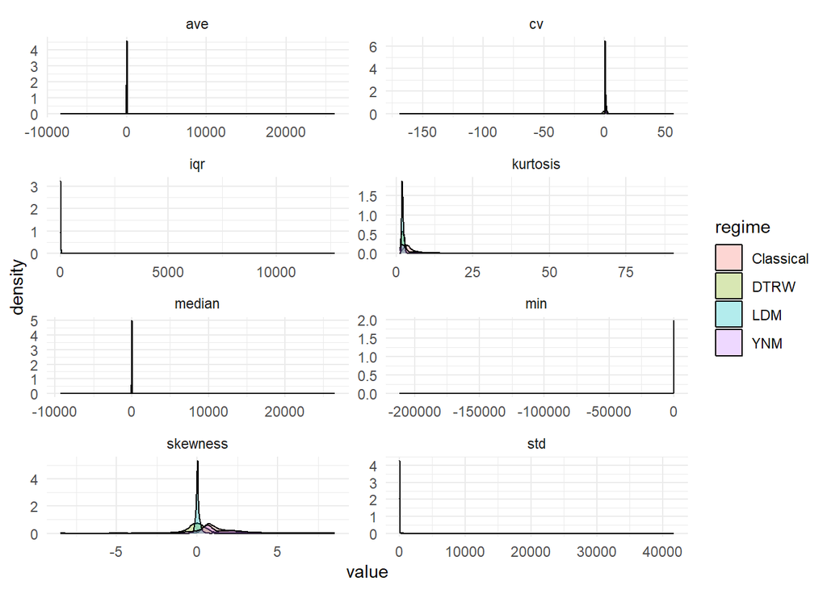

```r
plots[[1]]
```

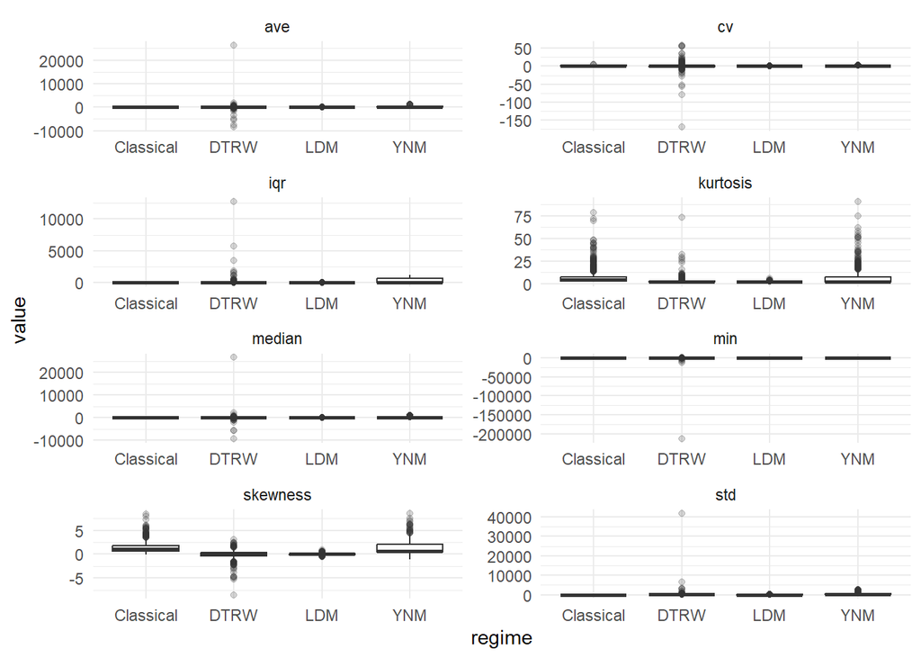

```r
plotsb[[1]]
```

# —– Feature removal —————————-

```r
remove_features = eta2_summary %>%
  filter(eta2 < 0.02)%>%
  pull(feature)

remove_features = c(remove_features, kw_summary %>%
  filter(p_value > 0.05) %>%
  pull(feature)
)

print(unique(remove_features))
```

```
##  [1] "median"                        "std"
##  [3] "logLik_rec_DTRW_norm"          "diff_sd"
##  [5] "diff_skew"                     "range"
##  [7] "rolling_var_instab.var_instab" "garch_acf"
##  [9] "cv"                            "diff_mean"
## [11] "logLik_rec_LDM_norm"           "min"
## [13] "dom_power"                     "logLik_rec_iid_gumbel"
## [15] "logLik_rec_LDM_gumbel"
```

Filtered feature set

```r
selected_features <- setdiff(names(feature_matrix), unique(remove_features))

feature_matrix_reduced <- feature_matrix %>%
  select(all_of(selected_features))
```